# Análise Exploratória - Comparação entre vendedores de diferentes lojas

Daniel

2024-08-08

# Análise Exploratória - Dataset de Vendedores

## Base de dados Employee

### Carregar dataset

```r
employee_dataset <- read.csv(file = 'employee_final.csv')
head(employee_dataset)
```

|  | id_employee | name | surname | cpf | status | role | initial_date | end_date | store_id |
| --- | --- | --- | --- | --- | --- | --- | --- | --- | --- |
| 1 | 643 | Antonella | da Cruz | 938.507.461-00 | ativo | gerente | 14/12/2007 |  | MG_21 |
| 2 | 924 | Carlos Eduardo | Alves | 501.639.827-59 | ativo | vendedor | 29/09/2014 |  | MG_21 |
| 3 | 567 | Ana Sophia | Ramos | 980.413.526-42 | ativo | vendedor | 03/04/2006 |  | MG_21 |
| 4 | 660 | Marcela | Brito | 859.163.742-91 | ativo | vendedor | 14/03/2003 |  | MG_21 |
| 5 | 297 | Leonardo | Porto | 652.341.890-15 | ativo | vendedor | 27/06/2021 |  | MG_23 |
| 6 | 523 | Heitor | Sales | 472.395.061-34 | ativo | vendedor | 11/09/2021 |  | MG_23 |

### Análise exploratória

```r
summary(employee_dataset)
```

```
##   id_employee         name             surname              cpf
##  Min.   :   1.0   Length:920         Length:920         Length:920
##  1st Qu.: 248.8   Class :character   Class :character   Class :character
##  Median : 492.5   Mode  :character   Mode  :character   Mode  :character
##  Mean   : 497.5
##  3rd Qu.: 750.2
##  Max.   :1000.0
##     status              role           initial_date         end_date
##  Length:920         Length:920         Length:920         Length:920
##  Class :character   Class :character   Class :character   Class :character
##  Mode  :character   Mode  :character   Mode  :character   Mode  :character
##
##
##
##    store_id
##  Length:920
##  Class :character
##  Mode  :character
##
##
##
```

```r
str(employee_dataset)
```

```
## 'data.frame':    920 obs. of  9 variables:
##  $ id_employee : int  643 924 567 660 297 523 264 834 693 417 ...
##  $ name        : chr  "Antonella" "Carlos Eduardo" "Ana Sophia" "Marcela" ...
##  $ surname     : chr  "da Cruz" "Alves" "Ramos" "Brito" ...
##  $ cpf         : chr  "938.507.461-00" "501.639.827-59" "980.413.526-42" "859.163.742-91" ...
##  $ status      : chr  "ativo" "ativo" "ativo" "ativo" ...
##  $ role        : chr  "gerente" "vendedor" "vendedor" "vendedor" ...
##  $ initial_date: chr  "14/12/2007" "29/09/2014" "03/04/2006" "14/03/2003" ...
##  $ end_date    : chr  "" "" "" "" ...
##  $ store_id    : chr  "MG_21" "MG_21" "MG_21" "MG_21" ...
```

```r
sapply(employee_dataset, function(x) sum(is.na(x)))
```

```
##  id_employee         name      surname          cpf       status         role
##            0            0            0            0            0            0
## initial_date     end_date     store_id
##            0            0            0
```

```r
employee_dataset$initial_date <- as.Date(employee_dataset$initial_date, format = "%d/%m/%Y")

employee_dataset$end_date <- as.Date(employee_dataset$end_date, format = "%d/%m/%Y")
```

```r
employee_dataset$store_id <- as.numeric(gsub("^[A-Za-z_ /]+", "", employee_dataset$store_id))


employee_dataset$store_id
```

```
##   [1]  21  21  21  21  23  23  23  23  24  24  24  24  26  26  26  26  29  29
##  [19]  29  29  34  34  34  34  36  36  36  36  37  37  37  37  39  39  39  39
##  [37]  39   5   5   5   5   5  54  54  54  54  54  54  70  70  70  70  80  80
##  [55]  80  80  11  11  11  11  11  13  13  13  13  13  13  15  15  15  15   2
##  [73]   2   2   2  23  23  23  23  23  23  23  28  28  28  28  28  28  29  29
##  [91]  29  29  33  33  33  33  33  38  38  38  38   4   4   4   4   4  47  47
## [109]  47  47  54  54  54  54  68  68  68  68  68  73  73  73  73  73  74  74
## [127]  74  74  78  78  78  78  89  89  89  89  90  90  90  90  90  93  93  93
## [145]  93  95  95  95  95  99  99  99  99  10  10  10  10  10  14  14  14  14
## [163]  14  16  16  16  16  23  23  23  23  24  24  24  24  24  28  28  28  28
## [181]  31  31  31  31  35  35  35  35  37  37  37  37  42  42  42  42  47  47
## [199]  47  47  50  50  50  50  50  54  54  54  54  54  56  56  56  56  57  57
## [217]  57  57  69  69  69  69  72  72  72  72  72  72  73  73  73  73  75  75
## [235]  75  75  75  75  82  82  82  82  82  91  91  91  91  91  98  98  98  98
## [253]  14  14  14  14  16  16  16  16  16  17  17  17  17  17   2   2   2   2
```

[output cut: 37 more lines]

### Analise Univariada

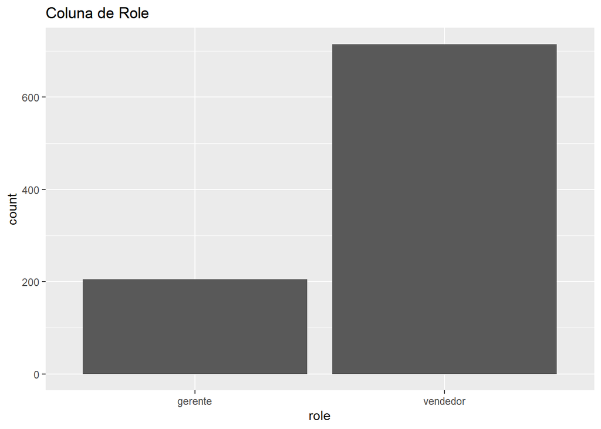

```r
status_freq <- table(employee_dataset$status)
role_freq <- table(employee_dataset$role)
store_id_freq <- table(employee_dataset$store_id)


ggplot(employee_dataset, aes(x = role)) +
  geom_bar() +
  ggtitle("Coluna de Role")
```

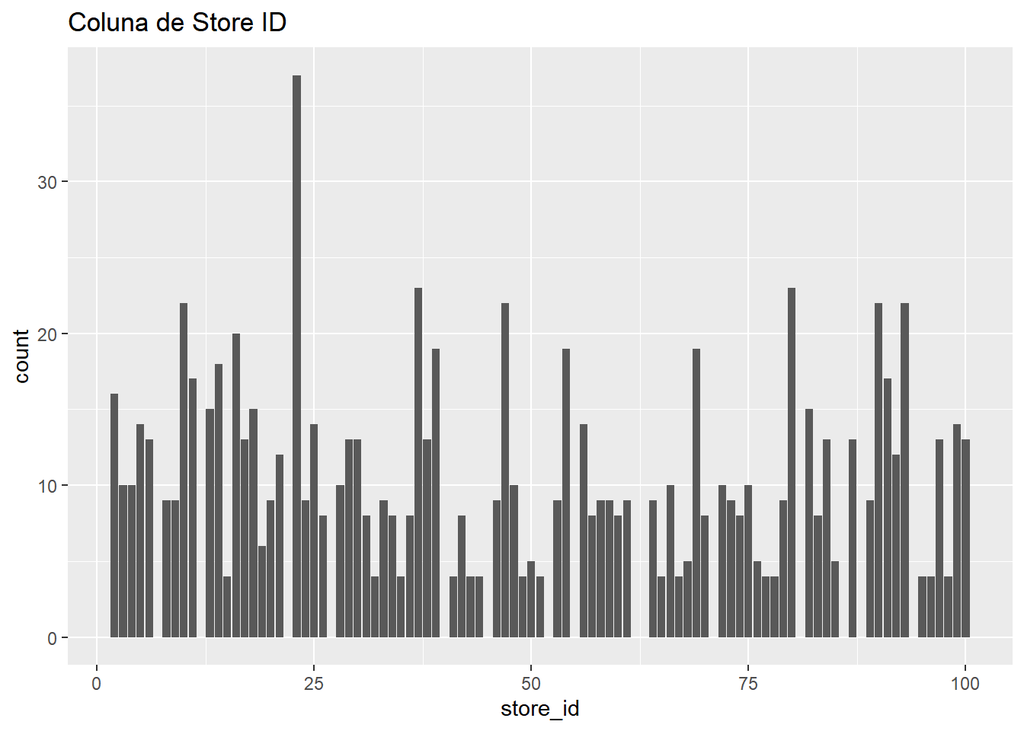

```r
ggplot(employee_dataset, aes(x = store_id)) +
  geom_bar() +
  ggtitle("Coluna de Store ID")
```

### Analise Bivariada

#### Distribuição por status

Primeiramente para fazer essa análise, iremos transformar a coluna de status de formato ch para binário, com a finalidade de aperfeiçoar a análise e visualização.

```r
employee_dataset$status <- ifelse(employee_dataset$status == "ativo", 1, 0)
```

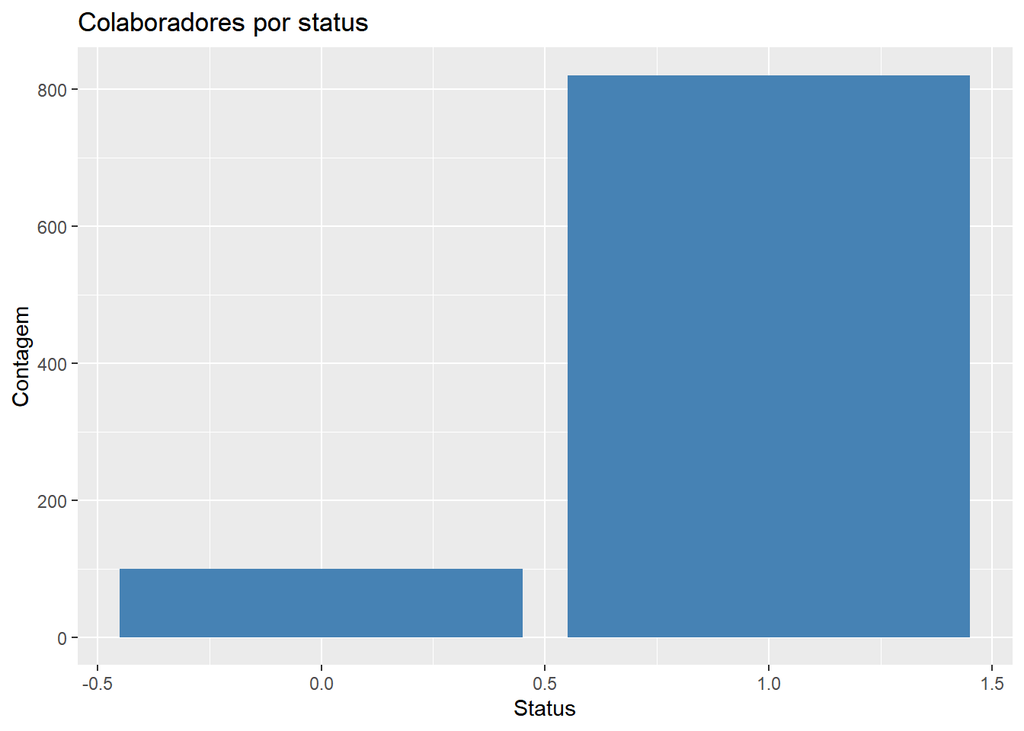

```r
ggplot(employee_dataset, aes(x = status)) +
  geom_bar(fill = "steelblue") +
  labs(title = "Colaboradores por status", x = "Status", y = "Contagem")
```

#### Outliers

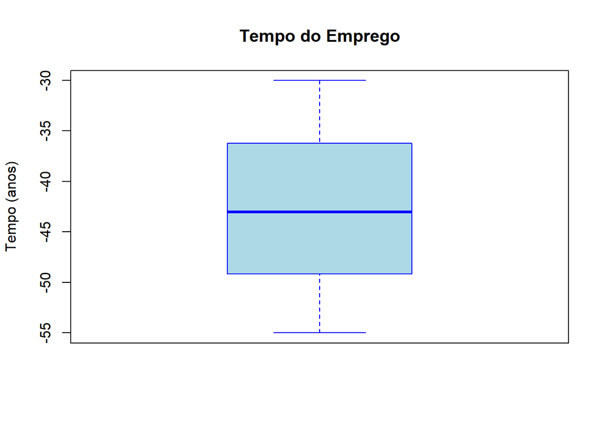

```r
employee_dataset$duration_years <- with(employee_dataset,
  as.numeric(difftime(
    ifelse(is.na(end_date), Sys.Date(), end_date),
    initial_date,
    units = "days"
  )) / 365
)


boxplot(employee_dataset$duration_years, main = "Tempo do Emprego", ylab = "Tempo (anos)", col = "lightblue", border = "blue")
```

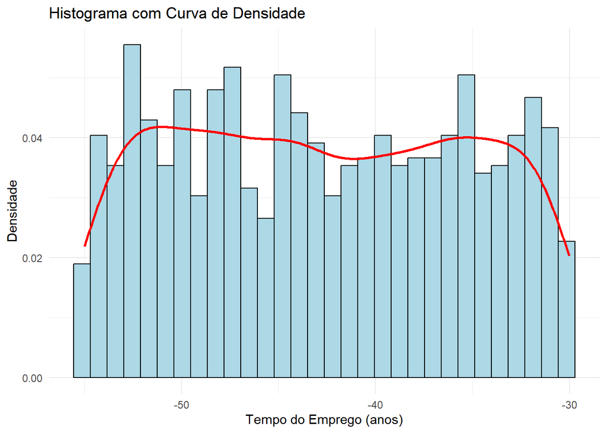

```r
ggplot(employee_dataset, aes(x = duration_years)) +
  geom_histogram(aes(y = ..density..), bins = 30, fill = "lightblue", color = "black") +
  geom_density(color = "red", linewidth = 1) +
  labs(title = "Histograma com Curva de Densidade", x = "Tempo do Emprego (anos)", y = "Densidade") +
  theme_minimal()
```

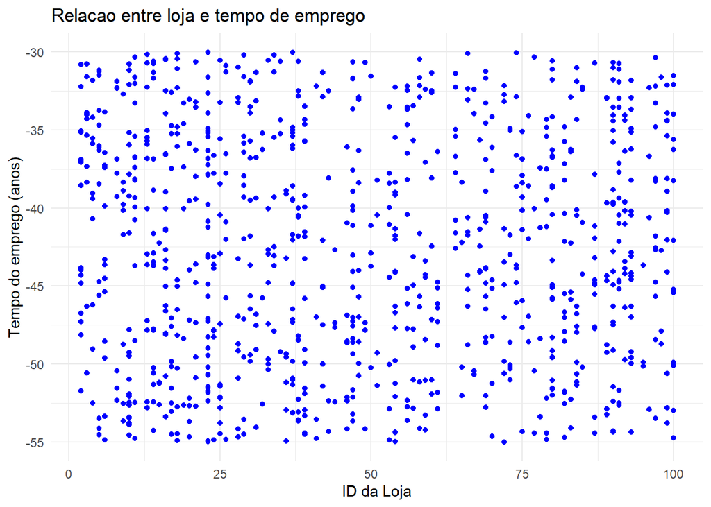

```r
ggplot(employee_dataset, aes(x = store_id, y = duration_years)) +
  geom_point(color = "blue") +
  labs(title = "Relacao entre loja e tempo de emprego", x = "ID da Loja", y = "Tempo do emprego (anos)") +
  theme_minimal()
```

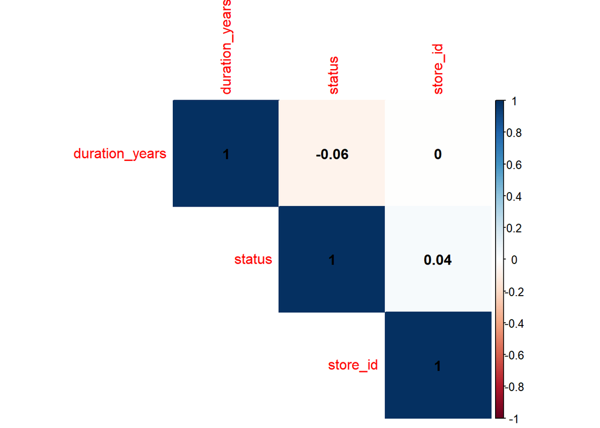

```r
employee_cor <- employee_dataset[, c("status", "duration_years", "store_id")]
cor_matrix <- cor(employee_cor, use = "complete.obs")
corrplot(cor_matrix, method = "color", type = "upper", order = "hclust", addCoef.col = "black")
```

### PCA

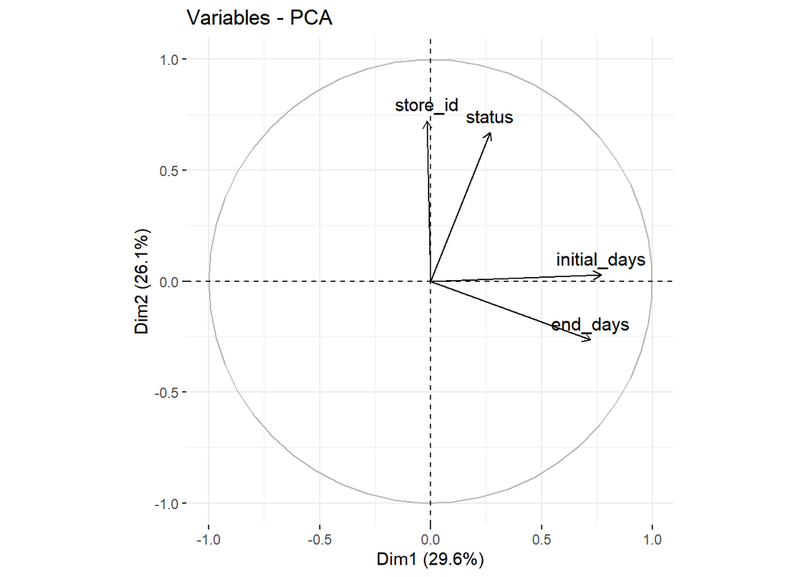

```r
min_date <- min(employee_dataset$initial_date, na.rm = TRUE)
employee_dataset <- employee_dataset %>%
  mutate(
    initial_days = as.numeric(difftime(initial_date, min_date, units = "days")),
    end_days = as.numeric(difftime(end_date, min_date, units = "days"))
  )


pca_data <- cbind(
  employee_dataset %>% select(initial_days, end_days,
  status,store_id)
)

pca_result <- PCA(pca_data, graph = FALSE)
fviz_pca_var(pca_result)
```

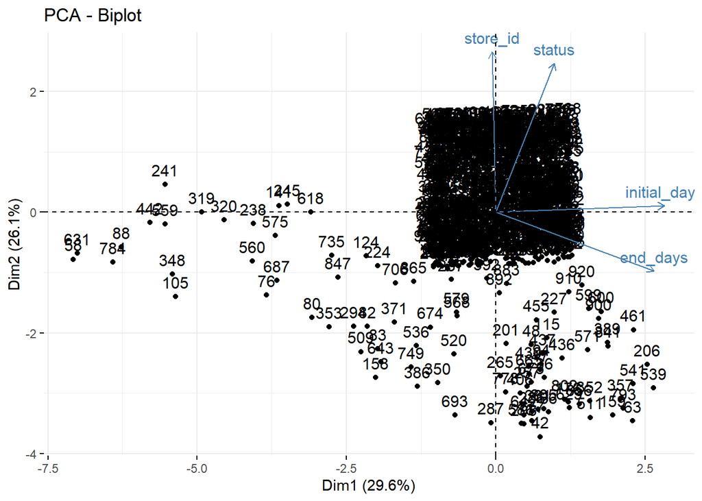

```r
fviz_pca_biplot(pca_result)
```

## Conclusão

### Descobertas

Para realizar a atividade, foi feita uma análise da base de dados employee_final.csv. Nas primeiras células é feita uma análise para reconhecimento da tabela, utilizando funções como str e summary, com elas descobrimos que a nossa base possui em sua maioria colunas de tipo chr, com exceção da coluna id_employee que é do tipo int.

Ao observar a tabela, vi que as colunas de datas, estavam em formato chr, então transformei ela em formato de date para melhorar as visualizações da análise.

Realizando a análise univariada, podemos ver a quantidade de dados nas colunas de role e store_id, podemos observar uma proporção de 1 gerente para 3 vendedores em cada loja e a distrubuição de funcionários por loja.

Na análise bivariada foi feita visualização de outliers, e relações entre a loja e o tempo de emprego dos funcionários.

### Discussões

Como a tabela analisada possui em sua maioria, dados qualitativos, foi bem difícil gerar análises de matriz de correlação e PCA, os que foram feitos não extraem muito valor para a análise, visto que foram feitos através de recategorização de dados como chr e date para numérico.

Contudo, através dessa análise podemos entender melhor o conjunto de dados que temos disponível e planejar como iremos associar essa tabela com as outras disponíveis, como por exemplo, a tabela de store_final e target_salesperson_final.